# 648_Lab01

Keyu Wan

2022-11-03

I want to use markdown to explore and visualize the relationship between the distances to nearest climbing wall of pictures on different social media.

## Set up

```r
setwd("D:/Umich/2022fall/EAS648_geovisualization/week1")
library(ggplot2)
library(sf)
library(tidyverse)
library(classInt)
library(viridis)
library(ggspatial)
library(grid)

boulder <- st_read("BoulderSocialMedia.shp")
```

## Analyze

```r
DBCD <- subset(boulder, DB ==  'Pano' | DB == 'Flickr')
t.test(Climb_dist~DB, data = DBCD)
```

```
##
##  Welch Two Sample t-test
##
## data:  Climb_dist by DB
## t = 6.3914, df = 522.36, p-value = 3.645e-10
## alternative hypothesis: true difference in means between group Flickr and group Pano is not equal to 0
## 95 percent confidence interval:
##   97.89498 184.77968
## sample estimates:
## mean in group Flickr   mean in group Pano
##             564.9160             423.5786
```

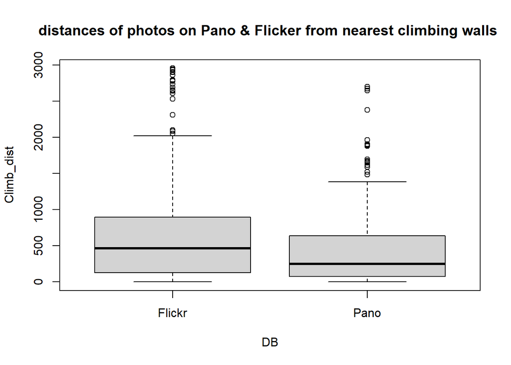

```r
boxplot(Climb_dist~DB, data = DBCD, main = 'distances of photos on Pano & Flicker from nearest climbing walls ')
```

In this section, I used t test to make sure that there is a difference in means of distance from the photos to the nearest climbing wall between Flickr and Pano since the p value is really small. And we can say that the mean distance of Flickr is 564.9160, and that of Pano is 423.5786. I show this difference by a boxplot.